# MachineLearningProject

Navnit Belur

May 24, 2015

Load the packages.

```r
library(dplyr)
```

```r
library(ggplot2)
library(caret)
library(rattle)
set.seed(42)
```

INTRODUCTION

This project looks at data captured from accelerometers on the bodies of participants. The aim is to classify for the data sets the actual activity being performed.

GETTING THE DATA

Load the training and test data sets. They are available at the below locations:

Training data set: https://d396qusza40orc.cloudfront.net/predmachlearn/pml-training.csv Testing data set: https://d396qusza40orc.cloudfront.net/predmachlearn/pml-testing.csv

```r
#training <- read.csv(url("https://d396qusza40orc.cloudfront.net/predmachlearn/pml-training.csv"))
#testing <- read.csv(url("https://d396qusza40orc.cloudfront.net/predmachlearn/pml-testing.csv"))
training <- read.csv("pml-training.csv")
testing <- read.csv("pml-testing.csv")
dim(training)
```

```
## [1] 19622   160
```

```r
dim(testing)
```

```
## [1]  20 160
```

The dependent variable in the data set is “classe” - the one we’d like to predict. This is a classification problem. We need to discover what other variables in the data set are the best candidates to use to train the prediction algorithm.

DATA CLEANING

Remove the first 5 columns as they are are information about users and also timestamps of the actvities.

```r
training <- select(training, -X, -user_name, -raw_timestamp_part_1, -raw_timestamp_part_2, -cvtd_timestamp)
dim(training)
```

```
## [1] 19622   155
```

Remove any “zero-variance predictors” that exist in the data set. Since these data do not vary, they are not very useful in generating the model. For this we will use the nearZeroVar function.

```r
nzv <- nearZeroVar(training)
training <- training[ , -nzv]
dim(training)
```

```
## [1] 19622    95
```

A lot of columns contain too many NAs to be considered for the model. We can remove such columns by removing those that have more than a threshold percentage (say 80% NAs). So we keep columns that contain >20%

```r
training <- training[, colSums(is.na(training)) < (0.8 * nrow(training))]
dim(training)
```

```
## [1] 19622    54
```

After the cleaning we’ve done, the number of variables from the original training set has gone down from 160 to 54 - the features we will use to create the model are:

```r
names(training)
```

```
##  [1] "num_window"           "roll_belt"            "pitch_belt"
##  [4] "yaw_belt"             "total_accel_belt"     "gyros_belt_x"
##  [7] "gyros_belt_y"         "gyros_belt_z"         "accel_belt_x"
## [10] "accel_belt_y"         "accel_belt_z"         "magnet_belt_x"
## [13] "magnet_belt_y"        "magnet_belt_z"        "roll_arm"
## [16] "pitch_arm"            "yaw_arm"              "total_accel_arm"
## [19] "gyros_arm_x"          "gyros_arm_y"          "gyros_arm_z"
## [22] "accel_arm_x"          "accel_arm_y"          "accel_arm_z"
## [25] "magnet_arm_x"         "magnet_arm_y"         "magnet_arm_z"
## [28] "roll_dumbbell"        "pitch_dumbbell"       "yaw_dumbbell"
## [31] "total_accel_dumbbell" "gyros_dumbbell_x"     "gyros_dumbbell_y"
## [34] "gyros_dumbbell_z"     "accel_dumbbell_x"     "accel_dumbbell_y"
## [37] "accel_dumbbell_z"     "magnet_dumbbell_x"    "magnet_dumbbell_y"
## [40] "magnet_dumbbell_z"    "roll_forearm"         "pitch_forearm"
## [43] "yaw_forearm"          "total_accel_forearm"  "gyros_forearm_x"
## [46] "gyros_forearm_y"      "gyros_forearm_z"      "accel_forearm_x"
## [49] "accel_forearm_y"      "accel_forearm_z"      "magnet_forearm_x"
## [52] "magnet_forearm_y"     "magnet_forearm_z"     "classe"
```

DATA PARTITIONING

We’ll use 70% of the avaialble “training” data to do the actual training and the other 30% for validation of the training as follows.

```r
inTrain <- createDataPartition(y = training$classe, p = 0.7, list = FALSE)
validation <- training[-inTrain, ]
training <- training[inTrain, ]
dim(training)
```

```
## [1] 13737    54
```

```r
dim(validation)
```

```
## [1] 5885   54
```

MACHINE LEARNING ALGORITHM

Model Fit 1

Using trees.

```r
rpartTree <- train(
                        classe ~ .,
                        method = "rpart",
                        data = training
                  )
print(rpartTree$finalModel)
```

```
## n= 13737
##
## node), split, n, loss, yval, (yprob)
##       * denotes terminal node
##
##  1) root 13737 9831 A (0.28 0.19 0.17 0.16 0.18)
##    2) roll_belt< 130.5 12581 8684 A (0.31 0.21 0.19 0.18 0.11)
##      4) pitch_forearm< -33.95 1113    7 A (0.99 0.0063 0 0 0) *
##      5) pitch_forearm>=-33.95 11468 8677 A (0.24 0.23 0.21 0.2 0.12)
##       10) magnet_dumbbell_y< 439.5 9691 6952 A (0.28 0.18 0.24 0.19 0.11)
##         20) roll_forearm< 123.5 5987 3545 A (0.41 0.18 0.18 0.17 0.06) *
##         21) roll_forearm>=123.5 3704 2466 C (0.08 0.17 0.33 0.23 0.18) *
##       11) magnet_dumbbell_y>=439.5 1777  861 B (0.029 0.52 0.041 0.22 0.2) *
##    3) roll_belt>=130.5 1156    9 E (0.0078 0 0 0 0.99) *
```

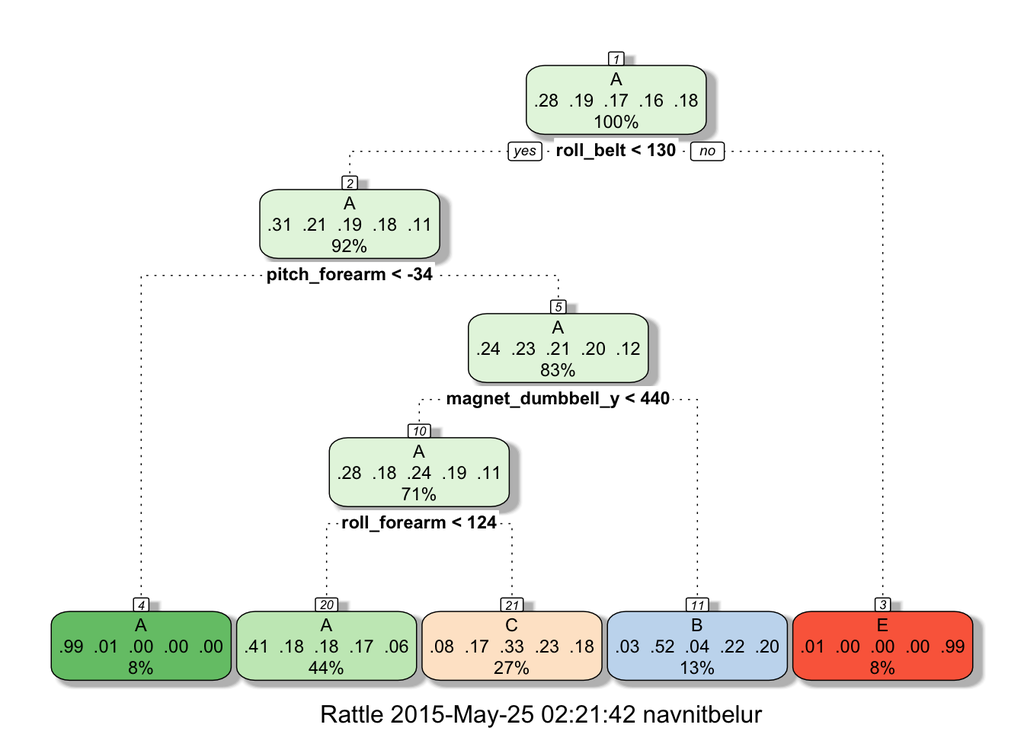

```r
fancyRpartPlot(rpartTree$finalModel)
```

```r
rpartTreePredictions <- predict(rpartTree$finalModel, newdata = validation, type = "class")
confusionMatrix(rpartTreePredictions, validation$classe)
```

```
## Confusion Matrix and Statistics
##
##           Reference
## Prediction    A    B    C    D    E
##          A 1532  481  501  445  162
##          B   29  370   36  179  138
##          C  108  288  489  340  298
##          D    0    0    0    0    0
##          E    5    0    0    0  484
##
## Overall Statistics
##
##                Accuracy : 0.4885
##                  95% CI : (0.4757, 0.5014)
##     No Information Rate : 0.2845
##     P-Value [Acc > NIR] : < 2.2e-16
##
##                   Kappa : 0.3306
##  Mcnemar's Test P-Value : NA
##
## Statistics by Class:
##
##                      Class: A Class: B Class: C Class: D Class: E
## Sensitivity            0.9152  0.32485  0.47661   0.0000  0.44732
## Specificity            0.6227  0.91951  0.78720   1.0000  0.99896
## Pos Pred Value         0.4909  0.49202  0.32108      NaN  0.98978
## Neg Pred Value         0.9486  0.85019  0.87689   0.8362  0.88918
## Prevalence             0.2845  0.19354  0.17434   0.1638  0.18386
## Detection Rate         0.2603  0.06287  0.08309   0.0000  0.08224
## Detection Prevalence   0.5303  0.12778  0.25879   0.0000  0.08309
## Balanced Accuracy      0.7689  0.62218  0.63190   0.5000  0.72314
```

Model Fit 2

This time using boosting. Hopefully, this will be a more accurate model than the first one.

```r
boostFit <- train(
                  classe ~ .,
                  method = "gbm",
                  data = training,
                  verbose = FALSE
                  )
boostPredictions <- predict(boostFit, newdata = validation)
boostConfusionMatrix <- confusionMatrix(boostPredictions, validation$classe)
boostConfusionMatrix
```

```
## Confusion Matrix and Statistics
##
##           Reference
## Prediction    A    B    C    D    E
##          A 1671   17    0    0    0
##          B    2 1113   13    2    5
##          C    0    6 1011   13    4
##          D    0    3    2  948   18
##          E    1    0    0    1 1055
##
## Overall Statistics
##
##                Accuracy : 0.9852
##                  95% CI : (0.9818, 0.9881)
##     No Information Rate : 0.2845
##     P-Value [Acc > NIR] : < 2.2e-16
##
##                   Kappa : 0.9813
##  Mcnemar's Test P-Value : NA
##
## Statistics by Class:
##
##                      Class: A Class: B Class: C Class: D Class: E
## Sensitivity            0.9982   0.9772   0.9854   0.9834   0.9750
## Specificity            0.9960   0.9954   0.9953   0.9953   0.9996
## Pos Pred Value         0.9899   0.9806   0.9778   0.9763   0.9981
## Neg Pred Value         0.9993   0.9945   0.9969   0.9967   0.9944
## Prevalence             0.2845   0.1935   0.1743   0.1638   0.1839
## Detection Rate         0.2839   0.1891   0.1718   0.1611   0.1793
## Detection Prevalence   0.2868   0.1929   0.1757   0.1650   0.1796
## Balanced Accuracy      0.9971   0.9863   0.9903   0.9894   0.9873
```

OK, so this model has a much better accuracy (close to 99%), so this is the one we’ll use for the prediction against the actual test data set.

TESTING and RESULTS

Now we use the boosting model to make the classification predictions against the actual testing data set and output to text files as required.

```r
answers <- as.character(predict(boostFit, newdata = testing))

pml_write_files = function(x) {
      n = length(x)
      for(i in 1:n) {
            filename = paste0("problem_id_", i, ".txt")
            write.table(x[i], file = filename, quote = FALSE, row.names = FALSE, col.names = FALSE)
      }
}

pml_write_files(answers)

answers
```

```
##  [1] "B" "A" "B" "A" "A" "E" "D" "B" "A" "A" "B" "C" "B" "A" "E" "E" "A"
## [18] "B" "B" "B"
```